# DS4A & Ciêcia de Dados Aplicada

Relatório Final: Pós Graduação - Cursos de Arquitetura e Design

Cecilia França Dib de Oliveira Bessa - 14/0134425

Thiago Canabrava Moreira - 14/0163859

Vitor Bertulucci Borges - 14/0171126

17 de Novembro de 2018

# 1. Introdução

## 1.1 Ciência de Dados

## 1.2 Cursos de Pós Graduação

### 1.2.1 Arquitetura e Urbanismo

Simultaneamente à criação da Universidade de Brasília em 1962, o Curso de Mestrado em Arquitetura foi iniciado como o primeiro do país nesta área. Em 1965 o curso foi sumariamente encerrado devido à crise política do período, retornando apenas em 1976 no quadro do 2o Plano Nacional de Desenvolvimento com a criação do Mestrado em Planejamento Urbano.

O objetivo principal era atender as demandas por capacitação de recursos humanos no campo das políticas públicas e do desenvolvimento das cidades, contando com apoio do então Conselho Nacional de Política Urbana da Secretaria de Planejamento. [1]

Em 1986, foi criado o Mestrado em Desenho Urbano para o estudo da configuração físico-espacial das cidades. Este programa se consolidou como um dos principais centros de irradiação de conhecimentos nas áreas de Planejamento e Desenho Urbano.

Com mais de 40 anos de existência, O Programa de Pesquisa e Pós-Graduação da Faculdade de Arquitetura e Urbanismo da Universidade de Brasília (PPG-FAU/UnB) enfrentou desafios e transformações. Na última década o perfil do corpo de docentes e pesquisadores perceberam a necessidade de uma nova estrutura para abranger as mudanças no Curso de Mestrado e a criação do Curso de Doutorado em Arquitetura e Urbanismo. Em 2002 a proposta foi aprovada pela CAPES.

As áreas de concentração de pesquisa em que o Programa se fundamenta são:

- *Teoria, história e crítica*

A área de concentração Teoria, História e Crítica realiza pesquisas em torno dos processos históricos de concepção, transformação e reflexão sobre arte, arquitetura e cidade. A formação nessa área transita desde os fundamentos epistemológicos e sociais da cultura material até a articulação crítica do pensamento sobre o patrimônio cultural, passando pelo estudo empírico e documental, com metodologias diversas e enfoque interdisciplinar. Acolhe recortes espaço-temporais diversos, com ênfase na região de Brasília em perspectiva diacrônica. [2]

- *Tecnologia, ambiente e sustentabilidade*

A área de Tecnologia, Ambiente e Sustentabilidade compreende estudos relativos a técnicas e processos ligados à produção da Arquitetura e do ambiente construído, com especial atenção à questão da sustentabilidade. Os sistemas estruturais são estudados no âmbito específico da Arquitetura e etapas da construção, desde os projetos e técnicas de produção até seu desempenho são objeto de pesquisas. O contexto urbano comparece com pesquisas relativas a qualidade do espaço e sua gestão, reabilitação em seus aspectos físicos e socioambientais. [2]

- *Projeto e Planejamento*

A área de Projeto e Planejamento abarca estudos sobre políticas, planos e gestão em escalas diversas, do edifício ao território. As pesquisas voltadas para o âmbito edilício envolvem estratégias projetuais, configuração, representação e acessibilidade. Entre os temas diversos dos estudos relacionados ao urbano, podem-se citar análises e proposições sobre planejamento urbano e territorial, legislação, reabilitação, regularização fundiária urbana e mobilidade. [2]

## 1.2.2 Design

# 2. CRISP-DM

## 2.2 Compreensão dos dados

### 2.2.1 Importando as bibliotecas

```r
library(jsonlite)
library(plyr)
library(dplyr)
library(stringr)
library(ggplot2)
library(tidyr)
```

## 2.2.2 Importando arquivos de publicações no formato JSON

```r
publicacoes_arquitetura <- fromJSON("ArquiteturaPos/235.publication.json")
publicacoes_design <- fromJSON("DesignPos/267.publication.json")
```

## 2.2.3 Descrição dos Dados

```r
head(publicacoes_arquitetura)
head(publicacoes_design)
```

[output not shown]

## 2.3.1 Transformando em *Dataframes*

```r
# Arquitetura
df_pub_arquitetura <- sapply(publicacoes_arquitetura, ldply, data.frame) %>% bind_rows() %>% as_tibble()

# Design
df_pub_design <- sapply(publicacoes_design, ldply, data.frame) %>% bind_rows() %>% as_tibble()
```

## 2.3.2 Descrição dos *Dataframes*

```r
# Arquitetura
head(df_pub_arquitetura)

# Design
head(df_pub_design)
```

[output not shown]

## 2.4 Preparação dos Dados

### 2.4.1 Separação de Publicações por autor

```r
# Arquitetura
pub_arquitetura_autores.endo <- df_pub_arquitetura %>% unnest(autores.endogeno) %>% distinct()

# Design
pub_design_autores.endo <- df_pub_design %>% unnest(autores.endogeno) %>% distinct()
```

### 2.4.2 Separação de Periódicos por Autor

```r
# Arquitetura
pub_arquitetura_periodicos <- pub_arquitetura_autores.endo %>% filter(is.element(pub_arquitetura_autores.endo$periodico, pub_arquitetura_autores.endo$ano))

# Design
pub_design_periodicos <- pub_design_autores.endo %>% filter(is.element(pub_design_autores.endo$periodico, pub_design_autores.endo$ano))
```

## 2.7 Desenvolvimento

### 2.7.1 Publicações por Ano

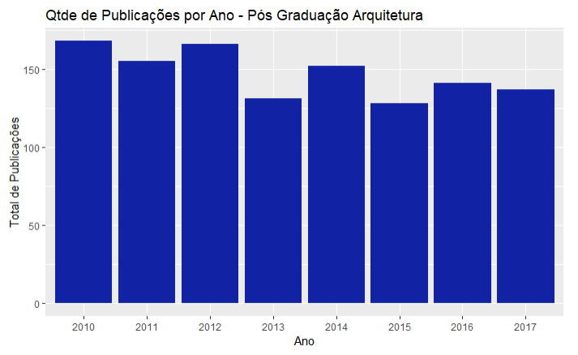

```r
# Arquitetura
ggplot(pub_arquitetura_periodicos, aes(x = .id )) +
ggtitle("Qtde de Publicações por Ano - Pós Graduação Arquitetura") +
labs(y = "Total de Publicações", x = "Ano") +
geom_histogram(stat ="count" ,fill = "#1123A4")
```

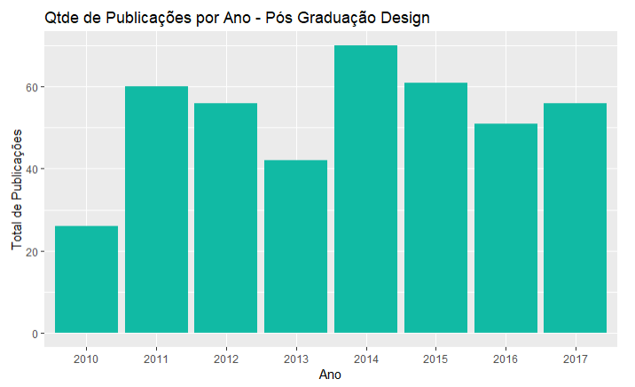

```r
# Design
ggplot(pub_design_periodicos, aes(x = .id )) +
ggtitle("Qtde de Publicações por Ano - Pós Graduação Design") +
labs(y = "Total de Publicações", x = "Ano") +
geom_histogram(stat ="count" ,fill = "#11BAA4")
```

# Referências

1. [Histórico da PGG - FAU](http://www.ppgfau.unb.br/institucional/historico-da-ppg-fau).
2. [Áreas de Concentração - FAU](http://www.ppgfau.unb.br/institucional/historico-da-ppg-fau).